# Yuba River

Sadie Gill, Mark Tompkins

June 11, 2019

## Future Data Improvements

none

## Instream Spawning and Rearing Habitat

### Combine Spawning and Rearing Data

The instream spawning and rearing habitat data described above for Fall Run Chinook Salmon (FR), Spring Run Chinook Salmon (SR), and Steelhead (ST) is combined for use in the DSM in the following format. Units are in square feet per 1000 feet.

| flow_cfs | FR_spawn_wua | FR_fry_wua | FR_juv_wua | SR_spawn_wua | ST_spawn_wua | ST_fry_wua | ST_juv_wua | ST_adult_wua | watershed |
| --- | --- | --- | --- | --- | --- | --- | --- | --- | --- |
| 150 | 3086.752 | 1901.940 | 42.92405 | 1211.406 | 63.60021 | 2472.573 | 1115.130 | NA | Yuba River |
| 250 | 3878.843 | 1746.204 | 61.60411 | 1892.588 | 162.49371 | 2718.746 | 1414.411 | NA | Yuba River |
| 300 | 4089.738 | 1778.598 | 71.34100 | 2129.055 | 223.07620 | 2846.064 | 1551.380 | 75292.67 | Yuba River |
| 350 | 4258.142 | 1747.218 | 80.22130 | 2315.054 | 286.41708 | 2880.195 | 1667.232 | 77960.78 | Yuba River |
| 400 | 10191.296 | 4080.976 | 1050.13045 | 5399.731 | 1079.34899 | 7674.502 | 3820.689 | 79850.13 | Yuba River |

*…with 45 more rows.*

### Spawning WUA

The instream spawning habitat weighted usable areas for Fall Run Chinook Salmon and Steelhead in the Yuba River.

#### Fall Run and Spring Run Chinook Salmon Spawning WUA Plot

The following plot shows the weighted usable spawning area in square feet per thousand feet of river for Fall Run Chinook Salmon and Spring Run Chinook Salmon. These area per length rates are multiplied by the total spawning reach length mapped by the SIT.

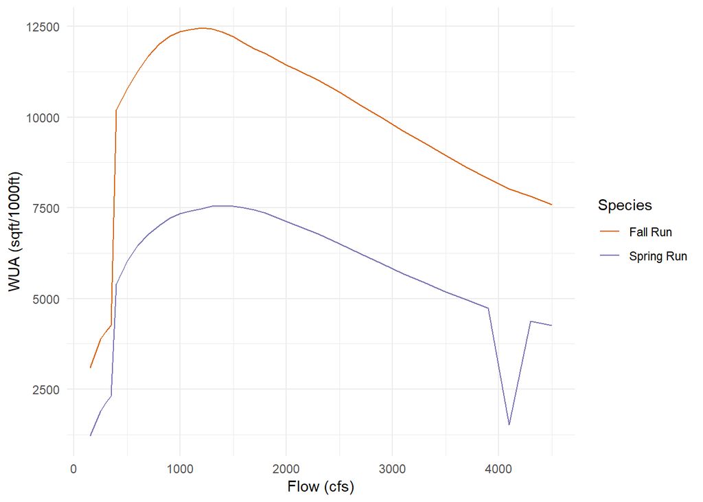

#### Steelhead Spawning WUA Plot

The following plot shows the weighted usable spawning area in square feet per thousand feet of river for Steelhead. These area per length rates are multiplied by the total spawning reach length mapped by the SIT.

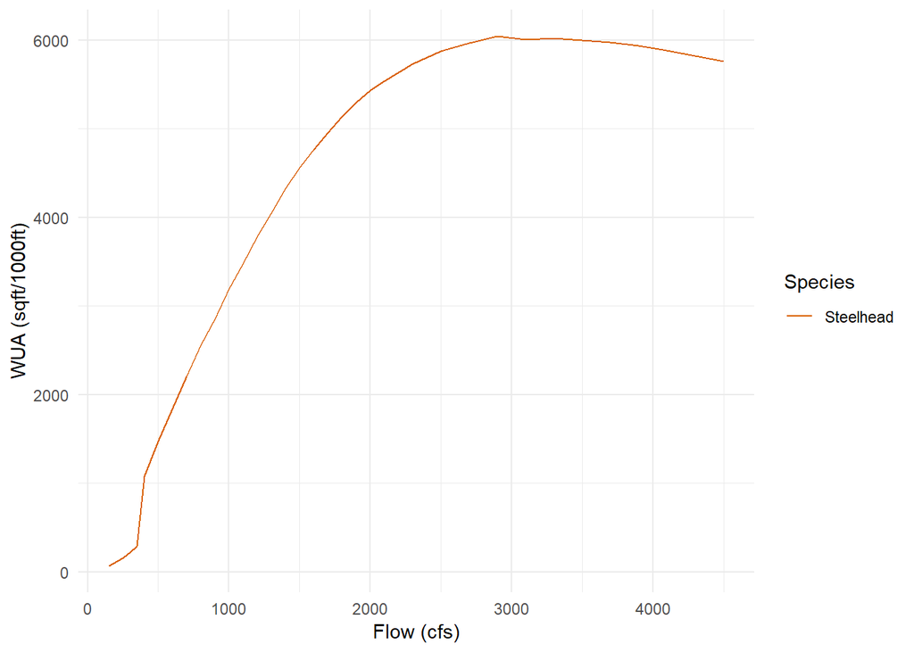

### Rearing WUA

The fry and juvenile instream rearing habitat weighted usable areas for Fall Run Chinook Salmon in the Yuba River.

#### Fall Run and Spring Run Chinook Salmon Rearing WUA Plot

The following plot shows the weighted usable rearing area in square feet per thousand feet of river for Fall Run Chinook Salmon and Spring Run Salmon fry and juvenile. These rates are multiplied by the total rearing reach length mapped by the SIT.

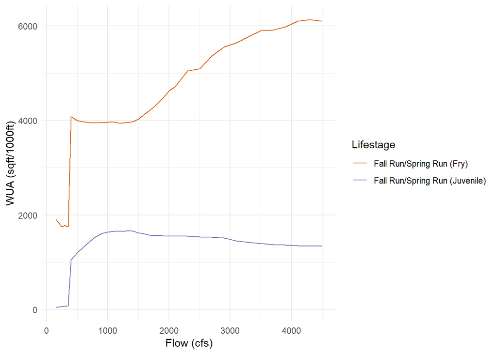

#### Steelhead Rearing WUA Plot

The following plot shows the weighted usable rearing area in square feet per thousand feet of river for Steelhead fry and juvenile. These rates are multiplied by the total rearing reach length mapped by the SIT.

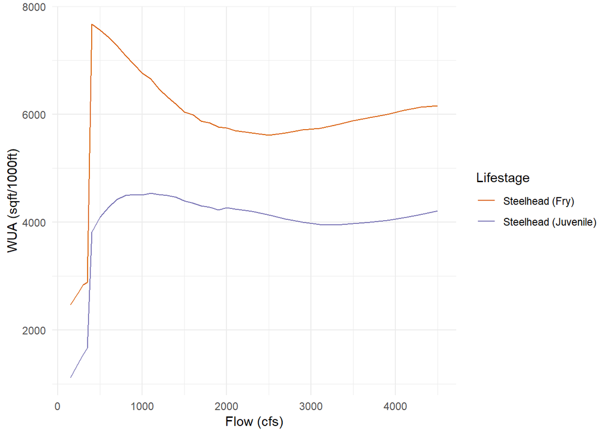